# Mobile Price Classification

Audhi Aprilliant

26 Desember 2018

### Context

Bob has started his own mobile company. He wants to give tough fight to big companies like Apple,Samsung etc. He does not know how to estimate price of mobiles his company creates. In this competitive mobile phone market you cannot simply assume things. To solve this problem he collects sales data of mobile phones of various companies. Bob wants to find out some relation between features of a mobile phone(eg:- RAM,Internal Memory etc) and its selling price. But he is not so good at Machine Learning. So he needs your help to solve this problem. In this problem you do not have to predict actual price but a price range indicating how high the price is

id: ID  
battery_power: Total energy a battery can store in one time measured in mAh  
blue: Has bluetooth or not  
clock_speed: speed at which microprocessor executes instructions  
dual_sim: Has dual sim support or not  
fc: Front Camera mega pixels  
four_g: Has 4G or not  
int_memory: Internal Memory in Gigabytes  
m_dep: Mobile Depth in cm  
mobile_wt: Weight of mobile phone  
n_cores: Number of cores of processor  
pc: Primary Camera mega pixels  
px_height: Pixel Resolution Height  
px_width: Pixel Resolution Width  
ram: Random Access Memory in Megabytes  
sc_h: Screen Height of mobile in cm  
sc_w: Screen Width of mobile in cm  
talk_time: longest time that a single battery charge will last when you are  
three_g: Has 3G or not  
touch_screen: Has touch screen or not  
wifi: Has wifi or not

```r
data = read.csv('D:/Audhi Aprilliant/IPB Works/Statistics Department/5th Semester/Quantitative Methods/Final Work/Mobile Price Classification/train.csv', header = TRUE, sep = ',')
str(data)
```

```
## 'data.frame':    2000 obs. of  21 variables:
##  $ battery_power: int  842 1021 563 615 1821 1859 1821 1954 1445 509 ...
##  $ blue         : int  0 1 1 1 1 0 0 0 1 1 ...
##  $ clock_speed  : num  2.2 0.5 0.5 2.5 1.2 0.5 1.7 0.5 0.5 0.6 ...
##  $ dual_sim     : int  0 1 1 0 0 1 0 1 0 1 ...
##  $ fc           : int  1 0 2 0 13 3 4 0 0 2 ...
##  $ four_g       : int  0 1 1 0 1 0 1 0 0 1 ...
##  $ int_memory   : int  7 53 41 10 44 22 10 24 53 9 ...
##  $ m_dep        : num  0.6 0.7 0.9 0.8 0.6 0.7 0.8 0.8 0.7 0.1 ...
##  $ mobile_wt    : int  188 136 145 131 141 164 139 187 174 93 ...
##  $ n_cores      : int  2 3 5 6 2 1 8 4 7 5 ...
##  $ pc           : int  2 6 6 9 14 7 10 0 14 15 ...
##  $ px_height    : int  20 905 1263 1216 1208 1004 381 512 386 1137 ...
##  $ px_width     : int  756 1988 1716 1786 1212 1654 1018 1149 836 1224 ...
##  $ ram          : int  2549 2631 2603 2769 1411 1067 3220 700 1099 513 ...
##  $ sc_h         : int  9 17 11 16 8 17 13 16 17 19 ...
##  $ sc_w         : int  7 3 2 8 2 1 8 3 1 10 ...
##  $ talk_time    : int  19 7 9 11 15 10 18 5 20 12 ...
##  $ three_g      : int  0 1 1 1 1 1 1 1 1 1 ...
##  $ touch_screen : int  0 1 1 0 1 0 0 1 0 0 ...
##  $ wifi         : int  1 0 0 0 0 0 1 1 0 0 ...
##  $ price_range  : int  1 2 2 2 1 1 3 0 0 0 ...
```

### Target Variable ‘Price Range’

```r
table(data$price_range)
```

```
##
##   0   1   2   3
## 500 500 500 500
```

```r
data$price_range = factor(data$price_range, levels = c('0','1','2','3'),
                          labels = c('Very Cheap','Cheap','Expensive','Very Expensive'))
price_range = data$price_range
round(prop.table(table(data$price_range))*100, digits = 1)
```

```
##
##     Very Cheap          Cheap      Expensive Very Expensive
##             25             25             25             25
```

```r
data = data[-21]
```

### Handling Categorical Variables

```r
colnames(data)[colnames(data)=='blue'] = 'blue.1'
data$blue.0 = NA
data$blue.0 = data$blue.1 - 1
data$blue.0 = abs(data$blue.0)

colnames(data)[colnames(data)=='dual_sim'] = 'dual_sim.1'
data$dual_sim.0 = NA
data$dual_sim.0 = data$dual_sim.1 - 1
data$dual_sim.0 = abs(data$dual_sim.0)

colnames(data)[colnames(data)=='four_g'] = 'four_g.1'
data$four_g.0 = NA
data$four_g.0 = data$four_g.1 - 1
data$four_g.0 = abs(data$four_g.0)

colnames(data)[colnames(data)=='three_g'] = 'three_g.1'
data$three_g.0 = NA
data$three_g.0 = data$three_g.1 - 1
data$three_g.0 = abs(data$three_g.0)

colnames(data)[colnames(data)=='touch_screen'] = 'touch_screen.1'
data$touch_screen.0 = NA
data$touch_screen.0 = data$touch_screen.1 - 1
data$touch_screen.0 = abs(data$touch_screen.0)

colnames(data)[colnames(data)=='wifi'] = 'wifi.1'
data$wifi.0 = NA
data$wifi.0 = data$wifi.1 - 1
data$wifi.0 = abs(data$wifi.0)
head(data)
```

|  | battery_power | blue.1 | clock_speed | dual_sim.1 | fc | four_g.1 | int_memory | m_dep | mobile_wt | n_cores | pc | px_height | px_width | ram | sc_h | sc_w | talk_time | three_g.1 | touch_screen.1 | wifi.1 | blue.0 | dual_sim.0 | four_g.0 | three_g.0 | touch_screen.0 | wifi.0 |
| --- | --- | --- | --- | --- | --- | --- | --- | --- | --- | --- | --- | --- | --- | --- | --- | --- | --- | --- | --- | --- | --- | --- | --- | --- | --- | --- |
| 1 | 842 | 0 | 2.2 | 0 | 1 | 0 | 7 | 0.6 | 188 | 2 | 2 | 20 | 756 | 2549 | 9 | 7 | 19 | 0 | 0 | 1 | 1 | 1 | 1 | 1 | 1 | 0 |
| 2 | 1021 | 1 | 0.5 | 1 | 0 | 1 | 53 | 0.7 | 136 | 3 | 6 | 905 | 1988 | 2631 | 17 | 3 | 7 | 1 | 1 | 0 | 0 | 0 | 0 | 0 | 0 | 1 |
| 3 | 563 | 1 | 0.5 | 1 | 2 | 1 | 41 | 0.9 | 145 | 5 | 6 | 1263 | 1716 | 2603 | 11 | 2 | 9 | 1 | 1 | 0 | 0 | 0 | 0 | 0 | 0 | 1 |
| 4 | 615 | 1 | 2.5 | 0 | 0 | 0 | 10 | 0.8 | 131 | 6 | 9 | 1216 | 1786 | 2769 | 16 | 8 | 11 | 1 | 0 | 0 | 0 | 1 | 1 | 0 | 1 | 1 |
| 5 | 1821 | 1 | 1.2 | 0 | 13 | 1 | 44 | 0.6 | 141 | 2 | 14 | 1208 | 1212 | 1411 | 8 | 2 | 15 | 1 | 1 | 0 | 0 | 1 | 0 | 0 | 0 | 1 |
| 6 | 1859 | 0 | 0.5 | 1 | 3 | 0 | 22 | 0.7 | 164 | 1 | 7 | 1004 | 1654 | 1067 | 17 | 1 | 10 | 1 | 0 | 0 | 1 | 0 | 1 | 0 | 1 | 1 |

### Combining Independent Variables with Target Variable

```r
data = cbind(data, price_range)
head(data)
```

|  | battery_power | blue.1 | clock_speed | dual_sim.1 | fc | four_g.1 | int_memory | m_dep | mobile_wt | n_cores | pc | px_height | px_width | ram | sc_h | sc_w | talk_time | three_g.1 | touch_screen.1 | wifi.1 | blue.0 | dual_sim.0 | four_g.0 | three_g.0 | touch_screen.0 | wifi.0 | price_range |
| --- | --- | --- | --- | --- | --- | --- | --- | --- | --- | --- | --- | --- | --- | --- | --- | --- | --- | --- | --- | --- | --- | --- | --- | --- | --- | --- | --- |
| 1 | 842 | 0 | 2.2 | 0 | 1 | 0 | 7 | 0.6 | 188 | 2 | 2 | 20 | 756 | 2549 | 9 | 7 | 19 | 0 | 0 | 1 | 1 | 1 | 1 | 1 | 1 | 0 | Cheap |
| 2 | 1021 | 1 | 0.5 | 1 | 0 | 1 | 53 | 0.7 | 136 | 3 | 6 | 905 | 1988 | 2631 | 17 | 3 | 7 | 1 | 1 | 0 | 0 | 0 | 0 | 0 | 0 | 1 | Expensive |
| 3 | 563 | 1 | 0.5 | 1 | 2 | 1 | 41 | 0.9 | 145 | 5 | 6 | 1263 | 1716 | 2603 | 11 | 2 | 9 | 1 | 1 | 0 | 0 | 0 | 0 | 0 | 0 | 1 | Expensive |
| 4 | 615 | 1 | 2.5 | 0 | 0 | 0 | 10 | 0.8 | 131 | 6 | 9 | 1216 | 1786 | 2769 | 16 | 8 | 11 | 1 | 0 | 0 | 0 | 1 | 1 | 0 | 1 | 1 | Expensive |
| 5 | 1821 | 1 | 1.2 | 0 | 13 | 1 | 44 | 0.6 | 141 | 2 | 14 | 1208 | 1212 | 1411 | 8 | 2 | 15 | 1 | 1 | 0 | 0 | 1 | 0 | 0 | 0 | 1 | Cheap |
| 6 | 1859 | 0 | 0.5 | 1 | 3 | 0 | 22 | 0.7 | 164 | 1 | 7 | 1004 | 1654 | 1067 | 17 | 1 | 10 | 1 | 0 | 0 | 1 | 0 | 1 | 0 | 1 | 1 | Cheap |

### Using caret and e1071 Packages

```r
library(caret)
library(e1071)
```

### Partitioning the Data into Training and Validation Data

```r
str(data)
```

```
## 'data.frame':    2000 obs. of  27 variables:
##  $ battery_power : int  842 1021 563 615 1821 1859 1821 1954 1445 509 ...
##  $ blue.1        : int  0 1 1 1 1 0 0 0 1 1 ...
##  $ clock_speed   : num  2.2 0.5 0.5 2.5 1.2 0.5 1.7 0.5 0.5 0.6 ...
##  $ dual_sim.1    : int  0 1 1 0 0 1 0 1 0 1 ...
##  $ fc            : int  1 0 2 0 13 3 4 0 0 2 ...
##  $ four_g.1      : int  0 1 1 0 1 0 1 0 0 1 ...
##  $ int_memory    : int  7 53 41 10 44 22 10 24 53 9 ...
##  $ m_dep         : num  0.6 0.7 0.9 0.8 0.6 0.7 0.8 0.8 0.7 0.1 ...
##  $ mobile_wt     : int  188 136 145 131 141 164 139 187 174 93 ...
##  $ n_cores       : int  2 3 5 6 2 1 8 4 7 5 ...
##  $ pc            : int  2 6 6 9 14 7 10 0 14 15 ...
##  $ px_height     : int  20 905 1263 1216 1208 1004 381 512 386 1137 ...
##  $ px_width      : int  756 1988 1716 1786 1212 1654 1018 1149 836 1224 ...
##  $ ram           : int  2549 2631 2603 2769 1411 1067 3220 700 1099 513 ...
##  $ sc_h          : int  9 17 11 16 8 17 13 16 17 19 ...
##  $ sc_w          : int  7 3 2 8 2 1 8 3 1 10 ...
##  $ talk_time     : int  19 7 9 11 15 10 18 5 20 12 ...
##  $ three_g.1     : int  0 1 1 1 1 1 1 1 1 1 ...
##  $ touch_screen.1: int  0 1 1 0 1 0 0 1 0 0 ...
##  $ wifi.1        : int  1 0 0 0 0 0 1 1 0 0 ...
##  $ blue.0        : num  1 0 0 0 0 1 1 1 0 0 ...
##  $ dual_sim.0    : num  1 0 0 1 1 0 1 0 1 0 ...
##  $ four_g.0      : num  1 0 0 1 0 1 0 1 1 0 ...
##  $ three_g.0     : num  1 0 0 0 0 0 0 0 0 0 ...
##  $ touch_screen.0: num  1 0 0 1 0 1 1 0 1 1 ...
##  $ wifi.0        : num  0 1 1 1 1 1 0 0 1 1 ...
##  $ price_range   : Factor w/ 4 levels "Very Cheap","Cheap",..: 2 3 3 3 2 2 4 1 1 1 ...
```

```r
set.seed(100)
index = createDataPartition(data$price_range, p = 0.7, list = FALSE)
train = data[index,]
validation = data[-index,]
```

### Exploring Data

```r
dim(train)
```

```
## [1] 1400   27
```

```r
dim(validation)
```

```
## [1] 600  27
```

```r
head(train)
```

|  | battery_power | blue.1 | clock_speed | dual_sim.1 | fc | four_g.1 | int_memory | m_dep | mobile_wt | n_cores | pc | px_height | px_width | ram | sc_h | sc_w | talk_time | three_g.1 | touch_screen.1 | wifi.1 | blue.0 | dual_sim.0 | four_g.0 | three_g.0 | touch_screen.0 | wifi.0 | price_range |
| --- | --- | --- | --- | --- | --- | --- | --- | --- | --- | --- | --- | --- | --- | --- | --- | --- | --- | --- | --- | --- | --- | --- | --- | --- | --- | --- | --- |
| 1 | 842 | 0 | 2.2 | 0 | 1 | 0 | 7 | 0.6 | 188 | 2 | 2 | 20 | 756 | 2549 | 9 | 7 | 19 | 0 | 0 | 1 | 1 | 1 | 1 | 1 | 1 | 0 | Cheap |
| 2 | 1021 | 1 | 0.5 | 1 | 0 | 1 | 53 | 0.7 | 136 | 3 | 6 | 905 | 1988 | 2631 | 17 | 3 | 7 | 1 | 1 | 0 | 0 | 0 | 0 | 0 | 0 | 1 | Expensive |
| 3 | 563 | 1 | 0.5 | 1 | 2 | 1 | 41 | 0.9 | 145 | 5 | 6 | 1263 | 1716 | 2603 | 11 | 2 | 9 | 1 | 1 | 0 | 0 | 0 | 0 | 0 | 0 | 1 | Expensive |
| 4 | 615 | 1 | 2.5 | 0 | 0 | 0 | 10 | 0.8 | 131 | 6 | 9 | 1216 | 1786 | 2769 | 16 | 8 | 11 | 1 | 0 | 0 | 0 | 1 | 1 | 0 | 1 | 1 | Expensive |
| 5 | 1821 | 1 | 1.2 | 0 | 13 | 1 | 44 | 0.6 | 141 | 2 | 14 | 1208 | 1212 | 1411 | 8 | 2 | 15 | 1 | 1 | 0 | 0 | 1 | 0 | 0 | 0 | 1 | Cheap |
| 7 | 1821 | 0 | 1.7 | 0 | 4 | 1 | 10 | 0.8 | 139 | 8 | 10 | 381 | 1018 | 3220 | 13 | 8 | 18 | 1 | 0 | 1 | 1 | 1 | 0 | 0 | 1 | 0 | Very Expensive |

```r
head(validation)
```

|  | battery_power | blue.1 | clock_speed | dual_sim.1 | fc | four_g.1 | int_memory | m_dep | mobile_wt | n_cores | pc | px_height | px_width | ram | sc_h | sc_w | talk_time | three_g.1 | touch_screen.1 | wifi.1 | blue.0 | dual_sim.0 | four_g.0 | three_g.0 | touch_screen.0 | wifi.0 | price_range |
| --- | --- | --- | --- | --- | --- | --- | --- | --- | --- | --- | --- | --- | --- | --- | --- | --- | --- | --- | --- | --- | --- | --- | --- | --- | --- | --- | --- |
| 6 | 1859 | 0 | 0.5 | 1 | 3 | 0 | 22 | 0.7 | 164 | 1 | 7 | 1004 | 1654 | 1067 | 17 | 1 | 10 | 1 | 0 | 0 | 1 | 0 | 1 | 0 | 1 | 1 | Cheap |
| 8 | 1954 | 0 | 0.5 | 1 | 0 | 0 | 24 | 0.8 | 187 | 4 | 0 | 512 | 1149 | 700 | 16 | 3 | 5 | 1 | 1 | 1 | 1 | 0 | 1 | 0 | 0 | 0 | Very Cheap |
| 9 | 1445 | 1 | 0.5 | 0 | 0 | 0 | 53 | 0.7 | 174 | 7 | 14 | 386 | 836 | 1099 | 17 | 1 | 20 | 1 | 0 | 0 | 0 | 1 | 1 | 0 | 1 | 1 | Very Cheap |
| 10 | 509 | 1 | 0.6 | 1 | 2 | 1 | 9 | 0.1 | 93 | 5 | 15 | 1137 | 1224 | 513 | 19 | 10 | 12 | 1 | 0 | 0 | 0 | 0 | 0 | 0 | 1 | 1 | Very Cheap |
| 12 | 1520 | 1 | 2.2 | 0 | 5 | 1 | 33 | 0.5 | 177 | 8 | 18 | 151 | 1005 | 3826 | 14 | 9 | 13 | 1 | 1 | 1 | 0 | 1 | 0 | 0 | 0 | 0 | Very Expensive |
| 13 | 1815 | 0 | 2.8 | 0 | 2 | 0 | 33 | 0.6 | 159 | 4 | 17 | 607 | 748 | 1482 | 18 | 0 | 2 | 1 | 0 | 0 | 1 | 1 | 1 | 0 | 1 | 1 | Cheap |

### Setting Levels for Both Training and Validation Data

```r
levels(train$price_range) = make.names(levels(factor(train$price_range)))
levels(validation$price_range) = make.names(levels(factor(validation$price_range)))
```

### Setting Up Train Controls

```r
repeats = 3
numbers = 10
tunel = 10

set.seed(1234)
x = trainControl(method = 'repeatedcv',
                 number = numbers,
                 repeats = repeats,
                 classProbs = TRUE)

knn_fit = train(price_range~.,
               data = train,
               method = 'knn',
               preProcess = c('center','scale'),
               trControl = x,
               tuneLength = 10)
knn_fit
```

```
## k-Nearest Neighbors
##
## 1400 samples
##   26 predictor
##    4 classes: 'Very.Cheap', 'Cheap', 'Expensive', 'Very.Expensive'
##
## Pre-processing: centered (26), scaled (26)
## Resampling: Cross-Validated (10 fold, repeated 3 times)
## Summary of sample sizes: 1260, 1260, 1260, 1260, 1260, 1260, ...
## Resampling results across tuning parameters:
##
##   k   Accuracy   Kappa
##    5  0.4123810  0.2165079
##    7  0.4340476  0.2453968
##    9  0.4585714  0.2780952
##   11  0.4626190  0.2834921
##   13  0.4728571  0.2971429
##   15  0.4892857  0.3190476
##   17  0.4954762  0.3273016
##   19  0.5054762  0.3406349
##   21  0.5111905  0.3482540
##   23  0.5114286  0.3485714
##
## Accuracy was used to select the optimal model using the largest value.
## The final value used for the model was k = 23.
```

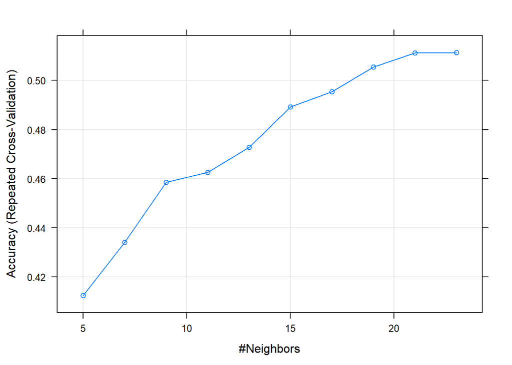

```r
plot(knn_fit)
```

### Making Predictions

```r
valid_pred = predict(knn_fit, validation)
```

### Storing Model Performance Scores

```r
confusionMatrix(valid_pred, validation$price_range)
```

```
## Confusion Matrix and Statistics
##
##                 Reference
## Prediction       Very.Cheap Cheap Expensive Very.Expensive
##   Very.Cheap             98    39         9              0
##   Cheap                  40    60        44             12
##   Expensive              11    37        63             41
##   Very.Expensive          1    14        34             97
##
## Overall Statistics
##
##                Accuracy : 0.53
##                  95% CI : (0.4892, 0.5705)
##     No Information Rate : 0.25
##     P-Value [Acc > NIR] : <2e-16
##
##                   Kappa : 0.3733
##  Mcnemar's Test P-Value : 0.8543
##
## Statistics by Class:
##
##                      Class: Very.Cheap Class: Cheap Class: Expensive
## Sensitivity                     0.6533       0.4000           0.4200
## Specificity                     0.8933       0.7867           0.8022
## Pos Pred Value                  0.6712       0.3846           0.4145
## Neg Pred Value                  0.8855       0.7973           0.8058
## Prevalence                      0.2500       0.2500           0.2500
## Detection Rate                  0.1633       0.1000           0.1050
## Detection Prevalence            0.2433       0.2600           0.2533
## Balanced Accuracy               0.7733       0.5933           0.6111
##                      Class: Very.Expensive
## Sensitivity                         0.6467
## Specificity                         0.8911
## Pos Pred Value                      0.6644
## Neg Pred Value                      0.8833
## Prevalence                          0.2500
## Detection Rate                      0.1617
## Detection Prevalence                0.2433
## Balanced Accuracy                   0.7689
```